# Script to work with Landsat bands derived from GEE

Alicia Valdés

03 julio 2026

# Load libraries

```r
library(signal)
library(tidyverse)
library(here)
library(lubridate)
library(dtplyr)
library(sf)
library(knitr)
library(mgcv)
library(future)
library(furrr)
library(progressr)
library(pracma)
```

# Load functions

```r
knitr::purl("functions_20260611.Rmd", output = "functions_20260611.R")
```

```
[1] "functions_20260611.R"
```

```r
source("functions_20260611.R")
```

# Supress package messages

```r
suppressPackageStartupMessages({
  library(mgcv)
  library(nlme)
})
```

# Load previously created objects

```r
load(file = "objects/data_RS_Landsat_bands_indices.Rdata")
load(file = "objects/GAM_data_Landsat.Rdata")
load(file = "objects/smoothed_data_Landsat.Rdata")
load(file = "objects/monthly_avg_indices_Landsat.Rdata")
```

# Load Resurvey db

```r
ReSurvey_data <- read_csv(
   here("data", "clean","ReSurvey_QRST_data_V2025.2_20260618.csv")) %>%
  select(PlotObservationID, RS_CODE, `ReSurvey site`, `ReSurvey plot`, EUNIS1,
         EUNIS2, `Location method`,  year, Lon_updated, Lat_updated,
         EUNIS_assignation) %>%
  mutate(PlotObservationID = factor(PlotObservationID),
         EUNIS1 = factor(EUNIS1), EUNIS2 = factor(EUNIS2))
```

# Read files with band data

I got these files using the GEE code prepared by Bea.

These files contain all observations in the ReSurvey database from all years. In order to avoid computation problems in GEE, biogeographical units that contain more than 4500 points have been subdivided in ArcGIS.

## From the observation year

```r
# Set the folder path
folder_path <- "C:/Data/MOTIVATE/MOTIVATE_RS_data/validation/Landsat/obs_year"

# List CSV files
csv_files <- list.files(folder_path, full.names = TRUE, recursive = TRUE)

# Read one file to get column names
sample_file <- csv_files[1]
sample_data <- read_csv(sample_file, n_max = 0)

# Read and process each file
data_list <- lapply(csv_files, function(file) {
  info <- extract_info(basename(file)) # Use only the filename

  # Read the file
  df <- read_csv(file) %>%
    mutate(biogeo = info$biogeo, unit = info$unit)

  return(df)
  })

# Combine all data
data_RS_Landsat_bands_obs <- bind_rows(data_list) %>%
  rename(PlotObservationID = PltObID) %>%
  select(-UNIT)

# View the resulting tibble
print(data_RS_Landsat_bands_obs)
```

```
# A tibble: 1,973,426 × 15
   `system:index`  Blue Green   NIR PlotObservationID   Red SWIR1 date       image_id time_utc
   <chr>          <dbl> <dbl> <dbl>             <dbl> <dbl> <dbl> <date>     <chr>    <time>
 1 59_1_1_1_LT05… 16809 16904 20890            346390 16488 15827 1984-06-07 1_1_1_L… 09:32
 2 59_1_1_1_LT05…  9343 10007 16716            346390  9766 13699 1984-10-13 1_1_1_L… 09:34
 3 59_1_1_1_LT05…  8468  8600 11207            346390  8699  8505 1984-10-29 1_1_1_L… 09:34
 4 59_1_1_1_LT05… 10238 11034 18162            346268 11384 17787 1984-10-13 1_1_1_L… 09:34
 5 59_1_1_1_LT05…  9419 10032 16720            346390  9787 12995 1984-10-13 1_1_1_L… 09:34
 6 59_1_1_1_LT05… 10212 11428 19190            346415 12091 18910 1984-10-13 1_1_1_L… 09:34
 7 59_1_1_1_LT05… 10780 12038 17743            346455 12626 16514 1984-10-13 1_1_1_L… 09:34
 8 59_1_1_1_LT05…  8999  8985 12343            346490  9055  9882 1984-10-13 1_1_1_L… 09:34
 9 59_1_1_1_LT05…  8992  9394 12968            346521  9054 10590 1984-10-13 1_1_1_L… 09:34
10 59_1_1_1_LT05… 10238 11034 18989            346554 11384 18632 1984-10-13 1_1_1_L… 09:34
# ℹ 1,973,416 more rows
# ℹ 5 more variables: timestamp <dbl>, year <dbl>, .geo <chr>, biogeo <chr>, unit <chr>
# ℹ Use `print(n = ...)` to see more rows
```

```r
# Counts per biogeo and unit
print(data_RS_Landsat_bands_obs %>% count(biogeo, unit), n = 100)
```

```
# A tibble: 28 × 3
   biogeo  unit          n
   <chr>   <chr>     <int>
 1 ALP     ALPS     115662
 2 ALP     ATRA       7847
 3 ALP     BALKAN     2003
 4 ALP     ENNINE      753
 5 ALP     NORDIC       20
 6 ALP     PYR         200
 7 ALP     ROMANIAN      6
 8 ARC     NORWAY      135
 9 ATL     BENELUX  308696
10 ATL     BRITAIN  206512
11 ATL     FRANCE     7980
12 ATL     IBERIA     2806
```

[output cut: 16 more lines]

## From the previous year

```r
# Set the folder path
folder_path <- "C:/Data/MOTIVATE/MOTIVATE_RS_data/validation/Landsat/prev_year"

# List CSV files
csv_files <- list.files(folder_path, full.names = TRUE, recursive = TRUE)

# Read one file to get column names
sample_file <- csv_files[1]
sample_data <- read_csv(sample_file, n_max = 0)

# Read and process each file
data_list <- lapply(csv_files, function(file) {
  info <- extract_info(basename(file)) # Use only the filename

  # Read the file
  df <- read_csv(file) %>%
    mutate(biogeo = info$biogeo, unit = info$unit)

  return(df)
  })

# Combine all data
data_RS_Landsat_bands_prev <- bind_rows(data_list) %>%
  rename(PlotObservationID = PltObID) %>%
  select(-UNIT)

# View the resulting tibble
print(data_RS_Landsat_bands_prev)
```

```
# A tibble: 1,926,225 × 17
   `system:index`           Blue Green   NIR PlotObservationID   Red SWIR1 date       image_id
   <chr>                   <dbl> <dbl> <dbl>             <dbl> <dbl> <dbl> <date>     <chr>
 1 60_1_1_1_LT05_192028_1… 15238 15770 18170            395018 15885 16411 1985-03-31 1_1_1_L…
 2 60_1_1_1_LT05_192028_1… 15436 16067 18637            395019 16017 17597 1985-03-31 1_1_1_L…
 3 60_1_1_1_LT05_192028_1… 10052 11263 18370            395012 12019 20620 1985-04-16 1_1_1_L…
 4 60_1_1_1_LT05_192028_1… 10323 11258 17746            395013 11882 19893 1985-04-16 1_1_1_L…
 5 60_1_1_1_LT05_192028_1…  9785 10514 15156            395014 10840 16862 1985-04-16 1_1_1_L…
 6 60_1_1_1_LT05_192028_1…  9720 10820 17513            395015 10842 18251 1985-04-16 1_1_1_L…
 7 60_1_1_1_LT05_192028_1…  9929 10818 15303            395016 11236 17159 1985-04-16 1_1_1_L…
 8 60_1_1_1_LT05_192028_1…  9790 10939 17874            395017 11086 18300 1985-04-16 1_1_1_L…
 9 60_1_1_1_LT05_192028_1…  9760 10806 17523            395018 10966 18061 1985-04-16 1_1_1_L…
10 60_1_1_1_LT05_192028_1…  9958 10951 17966            395019 10831 18661 1985-04-16 1_1_1_L…
# ℹ 1,926,215 more rows
# ℹ 8 more variables: image_year <dbl>, point_year <dbl>, time_utc <time>, timestamp <dbl>,
#   year <dbl>, .geo <chr>, biogeo <chr>, unit <chr>
# ℹ Use `print(n = ...)` to see more rows
```

```r
# Counts per biogeo and unit
print(data_RS_Landsat_bands_prev %>% count(biogeo, unit), n = 100)
```

```
# A tibble: 28 × 3
   biogeo  unit          n
   <chr>   <chr>     <int>
 1 ALP     ALPS     105710
 2 ALP     ATRA       7427
 3 ALP     BALKAN     2803
 4 ALP     ENNINE      520
 5 ALP     NORDIC       22
 6 ALP     PYR         215
 7 ALP     ROMANIAN      8
 8 ARC     NORWAY       38
 9 ATL     BENELUX  294832
10 ATL     BRITAIN  204378
11 ATL     FRANCE     8010
12 ATL     IBERIA     2536
```

[output cut: 16 more lines]

## From the posterior year

```r
# Set the folder path
folder_path <- "C:/Data/MOTIVATE/MOTIVATE_RS_data/validation/Landsat/post_year"

# List CSV files
csv_files <- list.files(folder_path, full.names = TRUE, recursive = TRUE)

# Read one file to get column names
sample_file <- csv_files[1]
sample_data <- read_csv(sample_file, n_max = 0)

# Read and process each file
data_list <- lapply(csv_files, function(file) {
  info <- extract_info(basename(file)) # Use only the filename

  # Read the file
  df <- read_csv(file) %>%
    mutate(biogeo = info$biogeo, unit = info$unit)

  return(df)
  })

# Combine all data
data_RS_Landsat_bands_post <- bind_rows(data_list) %>%
  rename(PlotObservationID = PltObID) %>%
  select(-UNIT)

# View the resulting tibble
print(data_RS_Landsat_bands_post)
```

```
# A tibble: 2,093,662 × 17
   `system:index`           Blue Green   NIR PlotObservationID   Red SWIR1 date       image_id
   <chr>                   <dbl> <dbl> <dbl>             <dbl> <dbl> <dbl> <date>     <chr>
 1 58_1_1_1_LT05_193028_1… 10143 11034 18369            346620 11384 17928 1984-10-13 1_1_1_L…
 2 58_1_1_1_LT05_194027_1…  9006 10194 18659            346620 10245 17805 1984-09-02 1_1_1_L…
 3 58_1_1_1_LT05_194028_1…  9001 10196 18493            346620 10244 17580 1984-09-02 1_1_1_L…
 4 59_1_1_1_LT05_193027_1…  8676  9580 17739            346390  9130 14456 1985-07-12 1_1_1_L…
 5 59_1_1_1_LT05_193027_1…  8673  9509 17734            346390  9132 14085 1985-08-29 1_1_1_L…
 6 59_1_1_1_LT05_193027_1…  9191  9785 18198            346390  9642 15921 1985-09-14 1_1_1_L…
 7 59_1_1_1_LT05_193027_1… 12438 11564  9529            346390 10465  7616 1985-11-17 1_1_1_L…
 8 59_1_1_1_LT05_193028_1… 10120 11133 19437            346268 10859 16028 1985-06-26 1_1_1_L…
 9 59_1_1_1_LT05_193028_1…  9598 10882 19342            346402 10745 16776 1985-06-26 1_1_1_L…
10 59_1_1_1_LT05_193028_1… 10200 11376 20001            346415 11424 17776 1985-06-26 1_1_1_L…
# ℹ 2,093,652 more rows
# ℹ 8 more variables: image_year <dbl>, point_year <dbl>, time_utc <time>, timestamp <dbl>,
#   year <dbl>, .geo <chr>, biogeo <chr>, unit <chr>
# ℹ Use `print(n = ...)` to see more rows
```

```r
# Counts per biogeo and unit
print(data_RS_Landsat_bands_post %>% count(biogeo, unit), n = 100)
```

```
# A tibble: 27 × 3
   biogeo  unit          n
   <chr>   <chr>     <int>
 1 ALP     ALPS     122285
 2 ALP     ATRA       8364
 3 ALP     BALKAN     2271
 4 ALP     ENNINE      441
 5 ALP     NORDIC       25
 6 ALP     PYR         255
 7 ALP     ROMANIAN      6
 8 ATL     BENELUX  320569
 9 ATL     BRITAIN  231209
10 ATL     FRANCE     8329
11 ATL     IBERIA     3004
12 BOR     FINLAND     108
13 BOR     NORDIC      889
14 CON     AUSTRIA  101290
15 CON     BALKAN      119
16 CON     FRANCE    53453
17 CON     GERMANY  196964
18 CON     ITALICA   11745
19 CON     NORDIC   836396
20 CON     POLAND    77583
21 CON     ROMANIA     116
22 MED     GREECE       11
23 MED     IBERIA    13811
24 MED     ITALICA   11524
25 MED     TIRRENO    5663
26 MED     TURKEY       70
27 PANONIA NA        87162
```

# Read file with band data for points outside polygons

Some points from the ReSurvey database fall outside the bioregion polygons. These points were manually assigned to the closest biogeo and unit in ArcGIS (those far out were assigned biogeo = OUT and unit = OUT). Data for these points has been extracted with a different GEE script.

## From the observation year

```r
data_RS_Landsat_bands_out_obs <- read_csv(
  "C:/Data/MOTIVATE/MOTIVATE_RS_data/validation/Landsat_out/AllPoints_Landsat_Annual.csv") %>%
  rename(biogeo = BIOGEO, unit = UNIT, PlotObservationID = PltObID)
```

Check that column names are the same:

```r
# Columns in data_RS_Landsat_bands_obs but not in data_RS_Landsat_bands_out
setdiff(names(data_RS_Landsat_bands_obs), names(data_RS_Landsat_bands_out_obs))
```

```
character(0)
```

```r
# Columns in data_RS_Landsat_bands_out but not in data_RS_Landsat_bands_obs
setdiff(names(data_RS_Landsat_bands_out_obs), names(data_RS_Landsat_bands_obs))
```

```
[1] "location"
```

## From the previous year

```r
data_RS_Landsat_bands_out_prev <- read_csv(
  "C:/Data/MOTIVATE/MOTIVATE_RS_data/validation/Landsat_out/AllPoints_Landsat_PREVIOUS_YEAR.csv") %>%
  rename(biogeo = BIOGEO, unit = UNIT, PlotObservationID = PltObID)
```

Check that column names are the same:

```r
# Columns in data_RS_Landsat_bands_prev but not in data_RS_Landsat_bands_out_prev
setdiff(names(data_RS_Landsat_bands_prev), names(data_RS_Landsat_bands_out_prev))
```

```
character(0)
```

```r
# Columns in data_RS_Landsat_bands_out_prev but not in data_RS_Landsat_bands_prev
setdiff(names(data_RS_Landsat_bands_out_prev), names(data_RS_Landsat_bands_prev))
```

```
[1] "location"
```

## From the posterior year

```r
data_RS_Landsat_bands_out_post <- read_csv(
  "C:/Data/MOTIVATE/MOTIVATE_RS_data/validation/Landsat_out/AllPoints_Landsat_POSTERIOR_YEAR.csv") %>%
  rename(biogeo = BIOGEO, unit = UNIT, PlotObservationID = PltObID)
```

Check that column names are the same:

```r
# Columns in data_RS_Landsat_bands_post but not in data_RS_Landsat_bands_out_post
setdiff(names(data_RS_Landsat_bands_post), names(data_RS_Landsat_bands_out_post))
```

```
character(0)
```

```r
# Columns in data_RS_Landsat_bands_out_post but not in data_RS_Landsat_bands_post
setdiff(names(data_RS_Landsat_bands_out_post), names(data_RS_Landsat_bands_post))
```

```
[1] "location"
```

# Join all data from inside polygons

```r
data_RS_Landsat_bands <- bind_rows(data_RS_Landsat_bands_obs,
                                   data_RS_Landsat_bands_prev,
                                   data_RS_Landsat_bands_post) %>%
  mutate(image_year = case_when(!is.na(image_year) ~ image_year,
                                TRUE ~ year(date)
                                ),
         point_year = case_when(!is.na(point_year) ~ point_year,
                                TRUE ~ year),
         year_cat = case_when(image_year == point_year ~ "obs",
                              image_year < point_year ~ "prev",
                              image_year > point_year ~ "post",
                              TRUE ~ NA_character_)
         )
```

# Join all data from outside polygons

```r
data_RS_Landsat_bands_out <- bind_rows(data_RS_Landsat_bands_out_obs,
                                       data_RS_Landsat_bands_out_prev,
                                       data_RS_Landsat_bands_out_post) %>%
  mutate(image_year = case_when(!is.na(image_year) ~ image_year,
                                TRUE ~ year(date)
                                ),
         point_year = case_when(!is.na(point_year) ~ point_year,
                                TRUE ~ year),
         year_cat = case_when(image_year == point_year ~ "obs",
                              image_year < point_year ~ "prev",
                              image_year > point_year ~ "post",
                              TRUE ~ NA_character_)
         )
```

# Join all data

```r
data_RS_Landsat_bands_all <- bind_rows(data_RS_Landsat_bands,
                                       data_RS_Landsat_bands_out) %>%
  select(-location)
```

# Some checks

Check that the year in the date of the images is not different to the sampling year:

```r
data_RS_Landsat_bands %>% dplyr::filter(year != year(date) & year_cat == "obs")
```

| system:index | Blue | Green | NIR | PlotObservationID | Red | SWIR1 | date | image_id | time_utc | timestamp | year | .geo | biogeo | unit | image_year | point_year | year_cat |
| --- | --- | --- | --- | --- | --- | --- | --- | --- | --- | --- | --- | --- | --- | --- | --- | --- | --- |

Check how many different images are for each observation, date and time:

```r
data_RS_Landsat_bands %>% group_by(PlotObservationID, date, time_utc) %>%
  summarise(n_images = n_distinct(image_id), .groups = "drop") %>%
  count(n_images)
```

| n_images | n |
| --- | --- |
| 1 | 5218701 |
| 2 | 387306 |

# Average the bands

When there is more than one image for each point and day, average the values of the bands:

# Calculate indices

Save:

Plot n_daytime:

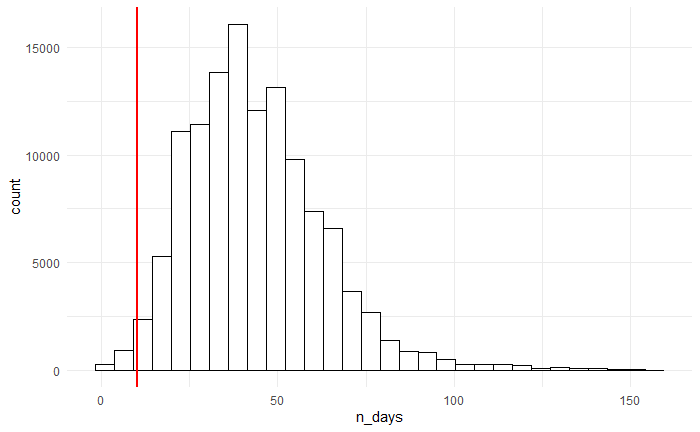

```r
data_RS_Landsat_bands_indices %>%
  group_by(PlotObservationID) %>%
  summarise(n_days = first(n_days)) %>% ungroup() %>%
  ggplot(aes(x = n_days)) + geom_histogram(color = "black", fill = "white") +
  geom_vline(xintercept = 10, color = "red", linewidth = 1) +
  theme_minimal()
```

# Compute phenological metrics from models fitted to time series data

## Calculation

Apply the function with batch processing

```r
plan(sequential)
```

## Number of plot observations with less than 10 DOYs

```r
data_RS_Landsat_bands_indices %>%
  dplyr::filter(PlotObservationID %in%
                  (ReSurvey_data %>%
                     distinct(PlotObservationID) %>%
                     pull(PlotObservationID))) %>%
  count(PlotObservationID) %>%
  dplyr::filter(n < 10) %>%
  nrow()
```

```
[1] 918
```

## Save

Look:

```r
GAM_data
```

| PlotObservationID | DOY | value | index | sos_slope | pos | eos_slope | auc_slope |
| --- | --- | --- | --- | --- | --- | --- | --- |
| 346268 | 136 | 0.108710624 | NDVI | 177 | 216 | 264 | 31.74696 |
| 346268 | 152 | 0.200905509 | NDVI | 177 | 216 | 264 | 31.74696 |
| 346268 | 177 | 0.313960962 | NDVI | 177 | 216 | 264 | 31.74696 |
| 346268 | 184 | 0.342911763 | NDVI | 177 | 216 | 264 | 31.74696 |
| 346268 | 193 | 0.376289421 | NDVI | 177 | 216 | 264 | 31.74696 |
| 346268 | 216 | 0.410913147 | NDVI | 177 | 216 | 264 | 31.74696 |
| 346268 | 232 | 0.383842375 | NDVI | 177 | 216 | 264 | 31.74696 |
| 346268 | 246 | 0.340496831 | NDVI | 177 | 216 | 264 | 31.74696 |
| 346268 | 264 | 0.296197927 | NDVI | 177 | 216 | 264 | 31.74696 |
| 346268 | 280 | 0.253619452 | NDVI | 177 | 216 | 264 | 31.74696 |

[output cut: 990 more lines]

Save as an object:

Add year to GAM_data:

```r
GAM_data <- GAM_data %>%
  left_join(data_RS_Landsat_bands_indices %>%
              select(PlotObservationID, year) %>%
              distinct(),
            by = "PlotObservationID")
```

## Extract average values of indices per month

Extract average values of indices per month and AUC between March and October;

Save as an object:

# Smooth the time series of NDMI and NDWI

Apply the function with batch processing.

```r
plan(sequential)
```

## Save

Look:

```r
smoothed_data
```

| PlotObservationID | DOY | index | value |
| --- | --- | --- | --- |
| 346268 | 136 | NDMI | -0.0309171307 |
| 346268 | 152 | NDMI | 0.0059024336 |
| 346268 | 177 | NDMI | 0.0908589873 |
| 346268 | 184 | NDMI | 0.1142892091 |
| 346268 | 193 | NDMI | 0.1396534160 |
| 346268 | 216 | NDMI | 0.1648677337 |
| 346268 | 232 | NDMI | 0.1390627045 |
| 346268 | 246 | NDMI | 0.0998657439 |
| 346268 | 264 | NDMI | 0.0587060163 |
| 346268 | 280 | NDMI | 0.0207155781 |

[output cut: 990 more lines]

Save as an object:

# Get indices data (max. and min.)

These maximum and minimum values are from the smoothed time series. For values in DOY 1–50 and DOY 315–end, the GAM smoothing function replaced the original values with the mean base value of observations during each of these respective periods (this has now been done for all indices, i.e. NDVI, EVI, SAVI, NDMI and NDWI).

```r
final_indices_data <- GAM_data %>%
  group_by(PlotObservationID, index) %>%
  summarise(max = max(value), min = min(value)) %>%
  ungroup() %>%
  pivot_wider(names_from = index, values_from = c(max, min),
              names_glue = "{index}_{.value}") %>%
  full_join(
    smoothed_data %>%
      group_by(PlotObservationID, index) %>%
      summarise(max = max(value), min = min(value)) %>%
      ungroup() %>%
      pivot_wider(names_from = index, values_from = c(max, min),
                  names_glue = "{index}_{.value}")
    )
```

# Get phenology data

Use GAM iter_3 to get dates of the moments, values at those moments and AUC (time-integrated indices) between SOS and EOS:

```r
# Join to get values at SOS, POS, EOS and auc
final_phenology_data <- GAM_data %>%
  mutate(
    stage = case_when(
      DOY == sos_slope ~ "sos",
      DOY == pos ~ "pos",
      DOY == eos_slope ~ "eos",
      TRUE ~ NA_character_
    )
  ) %>%
  dplyr::filter(!is.na(stage)) %>%
  select(PlotObservationID, index, stage, doy = DOY, value) %>%
  # Remove duplicate rows
  distinct() %>%
  pivot_wider(
    names_from = c(index, stage),
    values_from = c(doy, value),
    names_glue = "{index}_{stage}_{.value}"
  ) %>%
  # Convert list cols to regular numeric cols
  mutate(
    NDVI_sos_value = map_dbl(NDVI_sos_value, 1),
    NDVI_pos_value = map_dbl(NDVI_pos_value, 1),
    NDVI_eos_value = map_dbl(NDVI_eos_value, 1),
    EVI_sos_value = map_dbl(EVI_sos_value, 1),
    EVI_pos_value = map_dbl(EVI_pos_value, 1),
    EVI_eos_value = map_dbl(EVI_eos_value, 1),
    SAVI_sos_value = map_dbl(SAVI_sos_value, 1),
    SAVI_pos_value = map_dbl(SAVI_pos_value, 1),
    SAVI_eos_value = map_dbl(SAVI_eos_value, 1)
  ) %>%
  full_join(GAM_data %>%
              distinct(PlotObservationID, index, auc_slope) %>%
              rename(auc = auc_slope) %>%
              pivot_wider(names_from = index, values_from = c(auc),
                          names_glue = "{index}_{.value}"))
```

# Join indices and phenology data

```r
final_RS_data <- full_join(
  # Indices data (max and min)
  final_indices_data,
  # Average values of indices per month
  monthly_avg_indices %>%
    pivot_wider(names_from = index, values_from = c(avg_value_01:auc_mar_oct),
                names_glue = "{index}_{.value}")
  ) %>%
  full_join(
    # Phenology data
    final_phenology_data
    ) %>%
  # Sort cols in alphabetical order
  select(PlotObservationID, sort(names(.)[names(.) != "PlotObservationID"]))
```

# Add EUNIS codes

```r
final_RS_data <- ReSurvey_data %>% left_join(final_RS_data)
```

```r
data_RS_Landsat_bands_indices <- data_RS_Landsat_bands_indices %>%
  left_join(ReSurvey_data)
```

# Monthly spectrophenology per habitat type

```r
# Prepare the data
data_monthly_EUNIS1 <- data_RS_Landsat_bands_indices %>%
  mutate(month = month(date, label = TRUE, abbr = TRUE, locale="EN-us")) %>%
  group_by(month, EUNIS1) %>%
  summarise(
    mean_NDVI = mean(NDVI, na.rm = TRUE),
    sd_NDVI = sd(NDVI, na.rm = TRUE),
    n_NDVI = sum(!is.na(NDVI)),
    mean_EVI = mean(EVI, na.rm = TRUE),
    sd_EVI = sd(EVI, na.rm = TRUE),
    n_EVI = sum(!is.na(EVI)),
    mean_SAVI = mean(SAVI, na.rm = TRUE),
    sd_SAVI = sd(SAVI, na.rm = TRUE),
    n_SAVI = sum(!is.na(SAVI)),
    .groups = "drop"
  )

data_monthly_EUNIS1 <- data_monthly_EUNIS1 %>%
  # Add label with n
  left_join(data_monthly_EUNIS1 %>%
              group_by(EUNIS1) %>%
              summarise(n_total = sum(n_NDVI, na.rm = TRUE)),
            by = "EUNIS1") %>%
  mutate(EUNIS1_label = paste0(EUNIS1, " (n = ", n_total, ")"))

data_monthly_EUNIS2 <- data_RS_Landsat_bands_indices %>%
  mutate(month = month(date, label = TRUE, abbr = TRUE, locale="EN-us")) %>%
  group_by(month, EUNIS1, EUNIS2) %>%
  summarise(
    mean_NDVI = mean(NDVI, na.rm = TRUE),
    sd_NDVI = sd(NDVI, na.rm = TRUE),
    n_NDVI = sum(!is.na(NDVI)),
    mean_EVI = mean(EVI, na.rm = TRUE),
    sd_EVI = sd(EVI, na.rm = TRUE),
    n_EVI = sum(!is.na(EVI)),
    mean_SAVI = mean(SAVI, na.rm = TRUE),
    sd_SAVI = sd(SAVI, na.rm = TRUE),
    n_SAVI = sum(!is.na(SAVI)),
    .groups = "drop"
  )

data_monthly_EUNIS2 <- data_monthly_EUNIS2 %>%
  # Add label with n
  left_join(data_monthly_EUNIS2 %>%
              group_by(EUNIS2) %>%
              summarise(n_total = sum(n_NDVI, na.rm = TRUE)),
            by = "EUNIS2") %>%
  mutate(EUNIS2_label = paste0(EUNIS2, " (n = ", n_total, ")"))
```

## EUNIS level 1

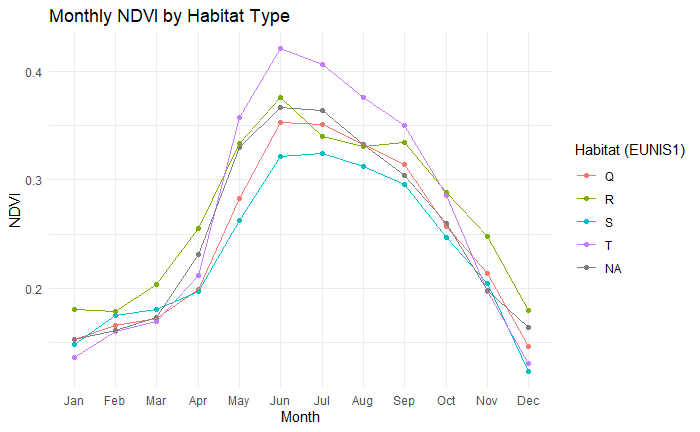

```r
# Plots

# EUNIS1
ggplot(data_monthly_EUNIS1,
       aes(x = month, y = mean_NDVI, color = EUNIS1,
           group = EUNIS1)) +
  geom_point() +
  geom_line(aes(group = EUNIS1)) +
  labs(
    title = "Monthly NDVI by Habitat Type",
    x = "Month",
    y = "NDVI",
    color = "Habitat (EUNIS1)"
  ) +
  theme_minimal()
ggsave(
  here("output", "figures", "monthly_spectrophenology_Landsat", "EUNIS1_NDVI.jpeg"),
  dpi = 300, width = 6, height = 2.5)
```

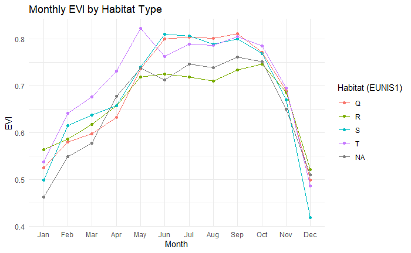

```r
ggplot(data_monthly_EUNIS1,
       aes(x = month, y = mean_EVI, color = EUNIS1,
           group = EUNIS1)) +
  geom_point() +
  geom_line() +
  labs(
    title = "Monthly EVI by Habitat Type",
    x = "Month",
    y = "EVI",
    color = "Habitat (EUNIS1)"
  ) +
  theme_minimal()
ggsave(
  here("output", "figures", "monthly_spectrophenology_Landsat", "EUNIS1_EVI.jpeg"),
  dpi = 300, width = 6, height = 2.5)
```

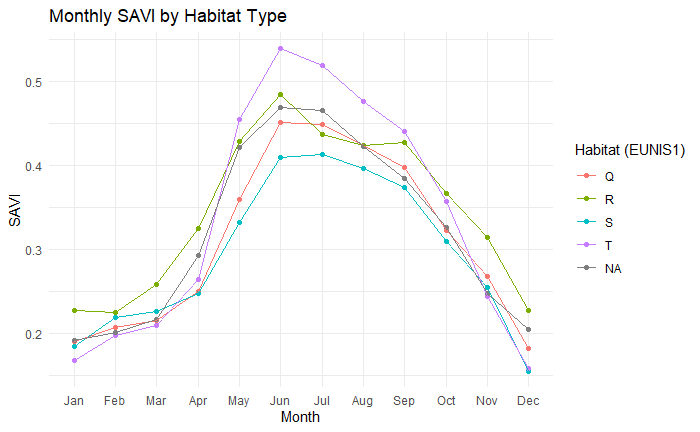

```r
ggplot(data_monthly_EUNIS1,
       aes(x = month, y = mean_SAVI, color = EUNIS1,
           group = EUNIS1)) +
  geom_point() +
  geom_line() +
  labs(
    title = "Monthly SAVI by Habitat Type",
    x = "Month",
    y = "SAVI",
    color = "Habitat (EUNIS1)"
  ) +
  theme_minimal()
ggsave(
  here("output", "figures", "monthly_spectrophenology_Landsat", "EUNIS1_SAVI.jpeg"),
  dpi = 300, width = 6, height = 2.5)
```

## EUNIS level 2

### Q

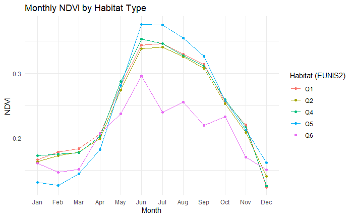

```r
# NDVI
ggplot(data_monthly_EUNIS2 %>%
         dplyr::filter(EUNIS1 == "Q" & !is.na(EUNIS2)) %>%
         # Remove those with EUNIS level 2 that does not match current classif
         dplyr::filter(EUNIS2 != "Qa" & EUNIS2 != "Qb"),
       aes(x = month, y = mean_NDVI, color = EUNIS2, group = EUNIS2)) +
  geom_point() +
  geom_line() +
  labs(
    title = "Monthly NDVI by Habitat Type",
    x = "Month",
    y = "NDVI",
    color = "Habitat (EUNIS2)"
  ) +
  theme_minimal()
ggsave(
  here("output", "figures", "monthly_spectrophenology_Landsat", "EUNIS2_Q_NDVI.jpeg"),
  dpi = 300, width = 7, height = 2.5)
```

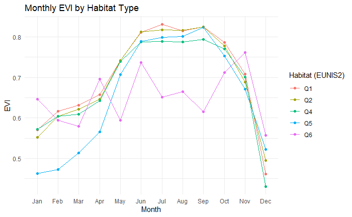

```r
# EVI
ggplot(data_monthly_EUNIS2 %>%
         dplyr::filter(EUNIS1 == "Q" & !is.na(EUNIS2)) %>%
         # Remove those with EUNIS level 2 that does not match current classif
         dplyr::filter(EUNIS2 != "Qa" & EUNIS2 != "Qb"),
       aes(x = month, y = mean_EVI, color = EUNIS2, group = EUNIS2)) +
  geom_point() +
  geom_line() +
  labs(
    title = "Monthly EVI by Habitat Type",
    x = "Month",
    y = "EVI",
    color = "Habitat (EUNIS2)"
  ) +
  theme_minimal()
ggsave(
  here("output", "figures", "monthly_spectrophenology_Landsat", "EUNIS2_Q_EVI.jpeg"),
  dpi = 300, width = 7, height = 2.5)
```

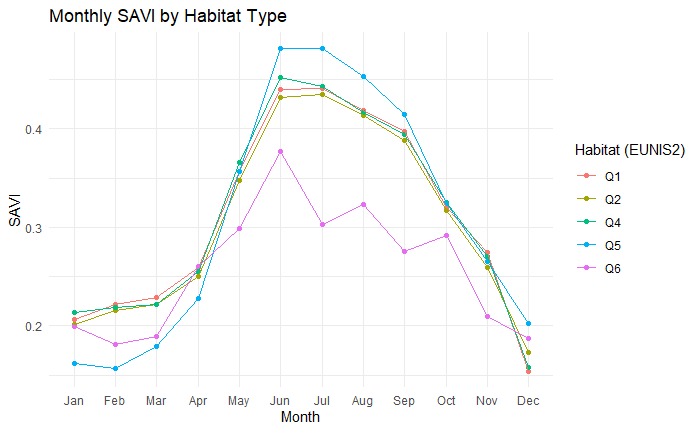

```r
# SAVI
ggplot(data_monthly_EUNIS2 %>%
         dplyr::filter(EUNIS1 == "Q" & !is.na(EUNIS2)) %>%
         # Remove those with EUNIS level 2 that does not match current classif
         dplyr::filter(EUNIS2 != "Qa" & EUNIS2 != "Qb"),
       aes(x = month, y = mean_SAVI, color = EUNIS2, group = EUNIS2)) +
  geom_point() +
  geom_line() +
  labs(
    title = "Monthly SAVI by Habitat Type",
    x = "Month",
    y = "SAVI",
    color = "Habitat (EUNIS2)"
  ) +
  theme_minimal()
ggsave(
  here("output", "figures", "monthly_spectrophenology_Landsat", "EUNIS2_Q_SAVI.jpeg"),
  dpi = 300, width = 7, height = 2.5)
```

### R

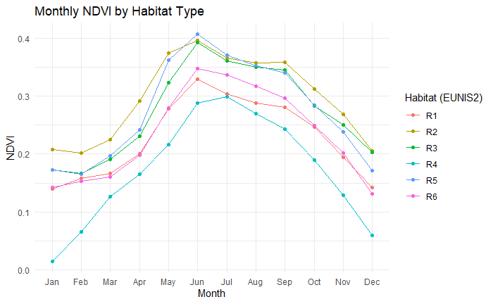

```r
ggplot(data_monthly_EUNIS2 %>%
         dplyr::filter(EUNIS1 == "R" & !is.na(EUNIS2)),
       aes(x = month, y = mean_NDVI, color = EUNIS2, group = EUNIS2)) +
  geom_point() +
  geom_line() +
  labs(
    title = "Monthly NDVI by Habitat Type",
    x = "Month",
    y = "NDVI",
    color = "Habitat (EUNIS2)"
  ) +
  theme_minimal()
ggsave(
  here("output", "figures", "monthly_spectrophenology_Landsat", "EUNIS2_R_NDVI.jpeg"),
  dpi = 300, width = 7, height = 2.5)
```

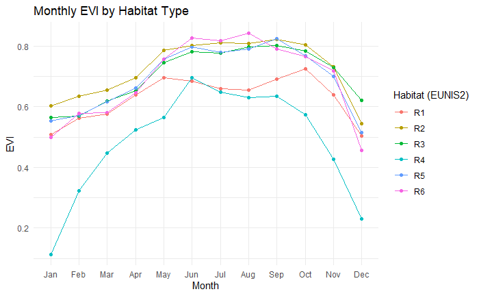

```r
ggplot(data_monthly_EUNIS2 %>%
         dplyr::filter(EUNIS1 == "R" & !is.na(EUNIS2)),
       aes(x = month, y = mean_EVI, color = EUNIS2, group = EUNIS2)) +
  geom_point() +
  geom_line() +
  labs(
    title = "Monthly EVI by Habitat Type",
    x = "Month",
    y = "EVI",
    color = "Habitat (EUNIS2)"
  ) +
  theme_minimal()
ggsave(
  here("output", "figures", "monthly_spectrophenology_Landsat", "EUNIS2_R_EVI.jpeg"),
  dpi = 300, width = 7, height = 2.5)
```

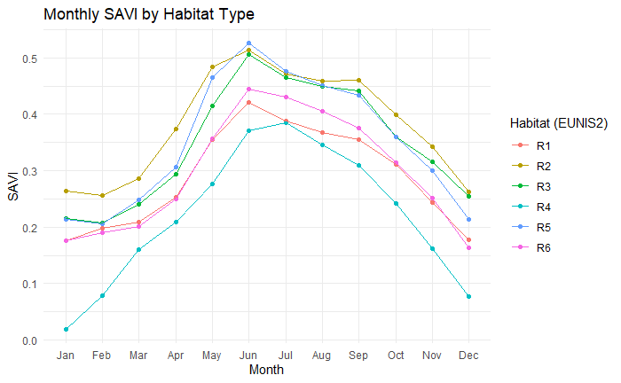

```r
ggplot(data_monthly_EUNIS2 %>%
         dplyr::filter(EUNIS1 == "R" & !is.na(EUNIS2)),
       aes(x = month, y = mean_SAVI, color = EUNIS2, group = EUNIS2)) +
  geom_point() +
  geom_line() +
  labs(
    title = "Monthly SAVI by Habitat Type",
    x = "Month",
    y = "SAVI",
    color = "Habitat (EUNIS2)"
  ) +
  theme_minimal()
ggsave(
  here("output", "figures", "monthly_spectrophenology_Landsat", "EUNIS2_R_SAVI.jpeg"),
  dpi = 300, width = 7, height = 2.5)
```

### S

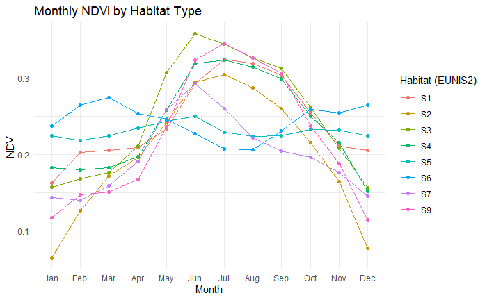

```r
ggplot(data_monthly_EUNIS2 %>%
         dplyr::filter(EUNIS1 == "S" & !is.na(EUNIS2)) %>%
         # Remove those with EUNIS level 2 that does not match current classif
         dplyr::filter(EUNIS2 != "Sa" & EUNIS2 != "Sb"),
       aes(x = month, y = mean_NDVI, color = EUNIS2, group = EUNIS2)) +
  geom_point() +
  geom_line() +
  labs(
    title = "Monthly NDVI by Habitat Type",
    x = "Month",
    y = "NDVI",
    color = "Habitat (EUNIS2)"
  ) +
  theme_minimal()
ggsave(
  here("output", "figures", "monthly_spectrophenology_Landsat", "EUNIS2_S_NDVI.jpeg"),
  dpi = 300, width = 8, height = 2.5)
```

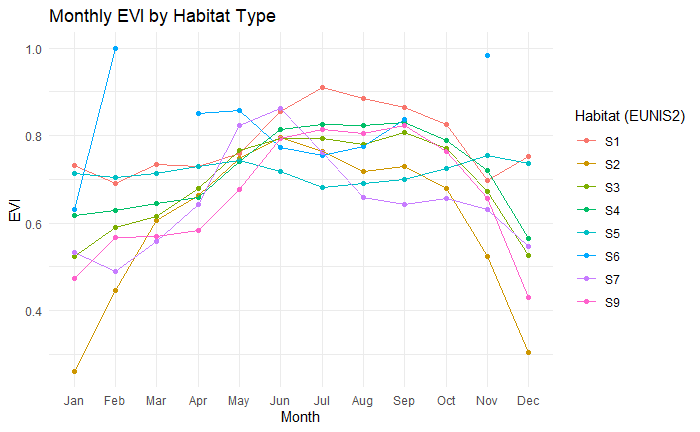

```r
ggplot(data_monthly_EUNIS2 %>%
         dplyr::filter(EUNIS1 == "S" & !is.na(EUNIS2)) %>%
         # Remove those with EUNIS level 2 that does not match current classif
         dplyr::filter(EUNIS2 != "Sa" & EUNIS2 != "Sb"),
       aes(x = month, y = mean_EVI, color = EUNIS2, group = EUNIS2)) +
  geom_point() +
  geom_line() +
  labs(
    title = "Monthly EVI by Habitat Type",
    x = "Month",
    y = "EVI",
    color = "Habitat (EUNIS2)"
  ) +
  theme_minimal()
ggsave(
  here("output", "figures", "monthly_spectrophenology_Landsat", "EUNIS2_S_EVI.jpeg"),
  dpi = 300, width = 8, height = 2.5)
```

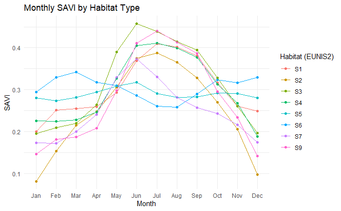

```r
ggplot(data_monthly_EUNIS2 %>%
         dplyr::filter(EUNIS1 == "S" & !is.na(EUNIS2)) %>%
         # Remove those with EUNIS level 2 that does not match current classif
         dplyr::filter(EUNIS2 != "Sa" & EUNIS2 != "Sb"),
       aes(x = month, y = mean_SAVI, color = EUNIS2, group = EUNIS2)) +
  geom_point() +
  geom_line() +
  labs(
    title = "Monthly SAVI by Habitat Type",
    x = "Month",
    y = "SAVI",
    color = "Habitat (EUNIS2)"
  ) +
  theme_minimal()
ggsave(
  here("output", "figures", "monthly_spectrophenology_Landsat", "EUNIS2_S_SAVI.jpeg"),
  dpi = 300, width = 8, height = 2.5)
```

### T

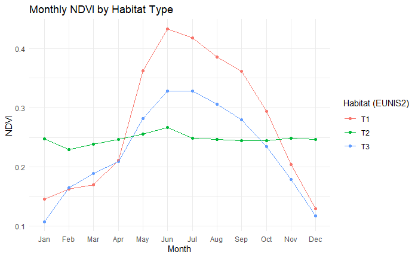

```r
ggplot(data_monthly_EUNIS2 %>%
         dplyr::filter(EUNIS1 == "T" & !is.na(EUNIS2)),
       aes(x = month, y = mean_NDVI, color = EUNIS2, group = EUNIS2)) +
  geom_point() +
  geom_line() +
  labs(
    title = "Monthly NDVI by Habitat Type",
    x = "Month",
    y = "NDVI",
    color = "Habitat (EUNIS2)"
  ) +
  theme_minimal()
ggsave(
  here("output", "figures", "monthly_spectrophenology_Landsat", "EUNIS2_T_NDVI.jpeg"),
  dpi = 300, width = 6, height = 2.5)
```

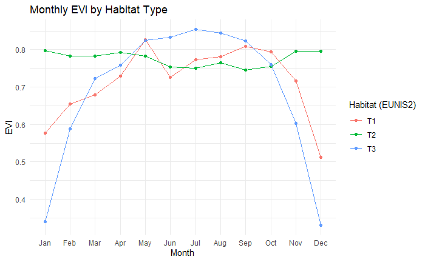

```r
ggplot(data_monthly_EUNIS2 %>%
         dplyr::filter(EUNIS1 == "T" & !is.na(EUNIS2)),
       aes(x = month, y = mean_EVI, color = EUNIS2, group = EUNIS2)) +
  geom_point() +
  geom_line() +
  labs(
    title = "Monthly EVI by Habitat Type",
    x = "Month",
    y = "EVI",
    color = "Habitat (EUNIS2)"
  ) +
  theme_minimal()
ggsave(
  here("output", "figures", "monthly_spectrophenology_Landsat", "EUNIS2_T_EVI.jpeg"),
  dpi = 300, width = 6, height = 2.5)
```

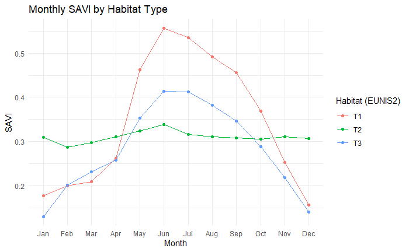

```r
ggplot(data_monthly_EUNIS2 %>%
         dplyr::filter(EUNIS1 == "T" & !is.na(EUNIS2)),
       aes(x = month, y = mean_SAVI, color = EUNIS2, group = EUNIS2)) +
  geom_point() +
  geom_line() +
  labs(
    title = "Monthly SAVI by Habitat Type",
    x = "Month",
    y = "SAVI",
    color = "Habitat (EUNIS2)"
  ) +
  theme_minimal()
ggsave(
  here("output", "figures", "monthly_spectrophenology_Landsat", "EUNIS2_T_SAVI.jpeg"),
  dpi = 300, width = 6, height = 2.5)
```

# Calculate other phenological metrics

```r
final_RS_data <- final_RS_data %>%
  mutate(
    # with slope method
    # Growing season duration
    NDVI_gsd = NDVI_eos_doy - NDVI_sos_doy,
    EVI_gsd = NDVI_eos_doy - NDVI_sos_doy,
    SAVI_gsd = SAVI_eos_doy - SAVI_sos_doy,
    # Difference in value between pos and sos
    NDVI_diff_pos_sos_value = NDVI_pos_value - NDVI_sos_value,
    EVI_diff_pos_sos_value = EVI_pos_value - EVI_sos_value,
    SAVI_diff_pos_sos_value = SAVI_pos_value - SAVI_sos_value,
    # Difference in value between pos and eos
    NDVI_diff_pos_eos_value = NDVI_pos_value - NDVI_eos_value,
    EVI_diff_pos_eos_value = EVI_pos_value - EVI_eos_value,
    SAVI_diff_pos_eos_value = SAVI_pos_value - SAVI_eos_value,
    # Difference in doy between pos and sos
    NDVI_diff_pos_sos_doy = NDVI_pos_doy - NDVI_sos_doy,
    EVI_diff_pos_sos_doy = EVI_pos_doy - EVI_sos_doy,
    SAVI_diff_pos_sos_doy = SAVI_pos_doy - SAVI_sos_doy,
    # Absolute difference in doy between pos and eos
    NDVI_diff_pos_eos_doy = abs(NDVI_pos_doy - NDVI_eos_doy),
    EVI_diff_pos_eos_doy = abs(EVI_pos_doy - EVI_eos_doy),
    SAVI_diff_pos_eos_doy = abs(SAVI_pos_doy - SAVI_eos_doy),
    # With months method
    # Difference in value between pos and march
    NDVI_diff_pos_march_value = NDVI_pos_value - NDVI_avg_value_03,
    EVI_diff_pos_march_value = EVI_pos_value - EVI_avg_value_03,
    SAVI_diff_pos_march_value = SAVI_pos_value - SAVI_avg_value_03,
    # Difference in value between pos and oct
    NDVI_diff_pos_oct_value = NDVI_pos_value - NDVI_avg_value_10,
    EVI_diff_pos_oct_value = EVI_pos_value - EVI_avg_value_10,
    SAVI_diff_pos_oct_value = SAVI_pos_value - SAVI_avg_value_10,
    # Difference in doy between pos and march
    NDVI_diff_pos_march_doy = NDVI_pos_doy - 75,
    EVI_diff_pos_march_doy = EVI_pos_doy - 75,
    SAVI_diff_pos_march_doy = SAVI_pos_doy - 75,
    # Difference in doy between pos and oct
    NDVI_diff_pos_oct_doy = abs(NDVI_pos_doy - 285),
    EVI_diff_pos_oct_doy = abs(EVI_pos_doy - 285),
    SAVI_diff_pos_oct_doy = abs(SAVI_pos_doy - 285)
  )
```

## Checks

### Slope method

```r
# Growing season duration should be positive
nrow(final_RS_data %>%
       dplyr::filter(NDVI_gsd <= 0 | EVI_gsd <= 0 |
                       SAVI_gsd <= 0))
```

```
[1] 0
```

```r
# Difference in value between pos and sos should be positive
nrow(final_RS_data %>%
       dplyr::filter(NDVI_diff_pos_sos_value <= 0))
```

```
[1] 48
```

```r
nrow(final_RS_data %>%
       dplyr::filter(EVI_diff_pos_sos_value <= 0))
```

```
[1] 1267
```

```r
nrow(final_RS_data %>%
       dplyr::filter(SAVI_diff_pos_sos_value <= 0))
```

```
[1] 36
```

```r
# Difference in value between pos and eos should be positive
nrow(final_RS_data %>%
       dplyr::filter(NDVI_diff_pos_eos_value <= 0))
```

```
[1] 380
```

```r
nrow(final_RS_data %>%
       dplyr::filter(EVI_diff_pos_eos_value <= 0))
```

```
[1] 6165
```

```r
nrow(final_RS_data %>%
       dplyr::filter(SAVI_diff_pos_eos_value <= 0))
```

```
[1] 357
```

```r
# Difference in doy between pos and sos should be positive
nrow(final_RS_data %>%
       dplyr::filter(NDVI_diff_pos_sos_doy <= 0 |
                       EVI_diff_pos_sos_doy <= 0 |
                       SAVI_diff_pos_sos_doy <= 0))
```

```
[1] 0
```

```r
# Difference in doy between eos and pos should be positive
nrow(final_RS_data %>%
       dplyr::filter(NDVI_diff_pos_eos_doy <= 0 |
                       EVI_diff_pos_eos_doy <= 0 |
                       SAVI_diff_pos_eos_doy <= 0))
```

```
[1] 0
```

## Further checks (EVI)

### Slope method

```r
# Difference in value between pos and sos should be positive
nrow(final_RS_data %>%
       dplyr::filter(EVI_diff_pos_sos_value <= 0))
```

```
[1] 1267
```

```r
# Difference in value between pos and eos should be positive
nrow(final_RS_data %>%
       dplyr::filter(EVI_diff_pos_eos_value <= 0))
```

```
[1] 6165
```

# Add some columns needed

```r
final_RS_data <- final_RS_data %>%
  left_join(
    data_RS_Landsat_bands_indices %>%
      distinct(PlotObservationID, year, biogeo, unit)
    )
```

# Add plotID, remove unneeded columns + add needed columns

```r
final_RS_data <- final_RS_data %>%
  mutate(plotID = paste(RS_CODE, `ReSurvey site`, `ReSurvey plot`, sep = "-")) %>%
  select(-RS_CODE, -`ReSurvey site`, -`ReSurvey plot`, -EUNIS2,
         -starts_with("EVI"), -matches("_(01|02|04|05|06|07|08|09|11|12)$"),
         -biogeo, -unit)
```

# Save to clean data

```r
write_tsv(final_RS_data,
          here("data", "clean","final_RS_data_bands_Landsat_all_20260702.csv"))
```